# ESM 232 Final Project - Snowy Plover Management

Jamie Miller and Donny Kim

8 June 2020

Our model estimates the impacts of different management strategies on the Vandenberg Air Force Base (VAFB) population the the threatened Western snowy plover. At breeding sites such as VAFB, several management strategies such as habitat restoration, lethal predator removal and non-lethal predator removal may be employed to protect the plover population. Each of these strategies protects a different plover life stage, but also requires funding and experienced personnel to conduct the management activities. We started with an age-structure Leslie Matrix Model to predict trends in the snowy plover populations. We then added habitat restoration and predator management submodels to predict how these management strategies may impact the plover population over a given number of years. This model can help wildlife biologists make strategic management decisions while considering funding and the best outcome for the managed species.

### 1. Set up Leslie Matrix for snowy plover age-structure population model

```r
# Four Age Classes: Egg, Chick, Juvenile, Adult
nclasses = 4

# create a growth matrix to store fecundity and survivorship information
gmatrix=matrix(nrow=nclasses, ncol=nclasses)
#gmatrix

# change NAs to zero
gmatrix[]=0.0
#gmatrix

# assign values for fecundity for each of the age classes
# notes that fecundity rates are births per capita (number in class) per time step
# At VAFB: average fledge succecss is 1.3 fledges per male; in 2019, 220 adults, 1156 eggs, 588 chicks, 134 fledges
### 1156/220 # 5.25 eggs per adult
### 220/1156 # 0.19 adults per egg; that makes no sense as a measure of fecundity

fecund =  c(0,0,0,5.25)

# enter into matrix
gmatrix[1,]=fecund

# Survivorship probabilities (to the next class) per time step, using 2019 data.
#588/1156 # 0.509 Hatch Rate, Chicks/Eggs
#134/588 # 0.228 Fledge rate, Fledges/Chicks

gmatrix[2,1]=0.509
gmatrix[3,2]=0.228
gmatrix[4,3]=0.33 #Adjust this number

# Adult survivorship to the following year
gmatrix[4,4]=0.6 #Adjust this number
gmatrix
```

```
##       [,1]  [,2] [,3] [,4]
## [1,] 0.000 0.000 0.00 5.25
## [2,] 0.509 0.000 0.00 0.00
## [3,] 0.000 0.228 0.00 0.00
## [4,] 0.000 0.000 0.33 0.60
```

Now use the matrix to grow a population

```r
# start with an initial population, lets say 1 individual in each class

p0 = c(1156,588,134,220)

# advance to the next time step
# use matrix multiplication
p1 = gmatrix %*% p0
#p1

# check if total number of individuals changed
#sum(p1)
#sum(p0)

# growth rate
sum(p1)/sum(p0)
```

```
## [1] 0.9788789
```

```r
#add another year
p2 = gmatrix %*% p1
p3 = gmatrix %*% p2

# combined
pop = cbind.data.frame(p0,p1,p2,p3)
pop$age = c("1_Eggs","2_Chicks","3_Juveniles","4_Adults")

popl = pop %>% gather(key="timestep",value="pop",-age)
#ggplot(popl, aes(timestep, pop,fill=as.factor(age)))+geom_col(position="dodge")+labs(fill="Age Group")

# I'm not sure this accomplishes what I want it to accomplish.
# Use the snpl.R function to incorporate habitat and predator submodels.
```

### 2. Use the snpl.R function to calculate the age structure model and predict adult population over time.

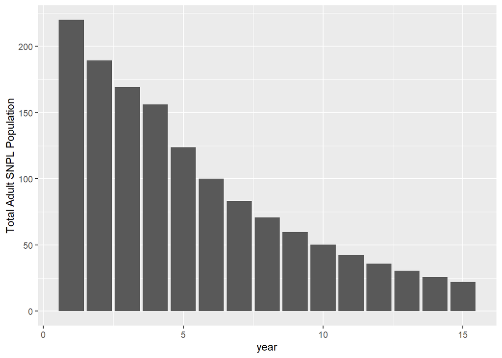

```r
source("../R/snpl.R")

# At VAFB: average fledge succecss is 1.3 fledges per male; in 2019, 220 adults, 1156 eggs, 588 chicks, 134 fledges
### 1156/220 # 5.25 eggs per adult
### 220/1156 # 0.19 adults per egg; that makes no sense as a measure of fecundity

# Fecundity Rates
F_adult = 5.25*0.6 # 1156/220 # 5.25 eggs per adult, M to F ratio of 0.6 (3 males to 2 females). represents number eggs per female; adjust for diff sex ratios

# Survivorship probabilities (to the next class) per time step, using 2019 data.
#588/1156 # 0.509 Hatch Rate, Chicks/Eggs
#134/588 # 0.228 Fledge rate, Fledges/Eggs

# Survivorship - based on 2019 survival probabilities
p_egg = 50.9/100 # Hatch rate
p_chick = 22.8/100 # Fledge rate
p_fledge = 33/100 # First Winter Survival, assume 33% make it; Adjust this value as needed.
p_adult = 66/100 # Adult survivorship, assume 66% make it; Adjust this value as needed.


# initial population parameters
# In 2019, 1156 eggs, 588 chicks, 134 fledges, 220 adults
ini = c(1156,588,134,220)
n_years = 15
fert_snpl = c(0,0,0,F_adult)
surv_snpl = c(p_egg,p_chick,p_fledge,p_adult)
K = 1000 # VAFB Carrying capacity, based on Recover Goals; can adjust
   ### K is not working in the model the way I think it should. Want it to apply only to adults, but it is applying to all life stages.
   ### Consider removing K from model and representing this information graphically.
### ===================================================================================
### changed code in snpl.R(line 41~44), and now K only applies to adult population. ###
### ===================================================================================

snpl_pop=snpl_popK(fert_snpl, surv_snpl, ini, n_years,K) # Population Structure

#head(snpl_pop)

# Plot adult population by year
year = seq(from=1, to=n_years)
snpl_tot = cbind.data.frame(year=year, adult_pop=snpl_pop$pop_structure[4,])

ggplot(snpl_tot, aes(year, adult_pop)) +
         geom_col() +
         labs(y="Total Adult SNPL Population")
```

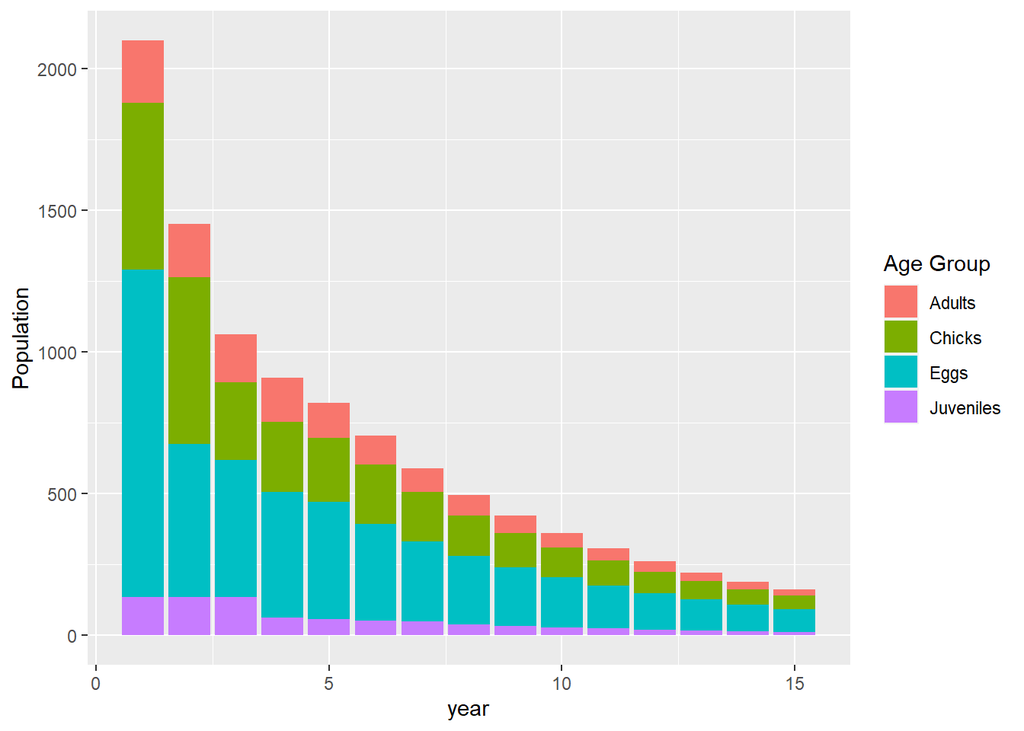

```r
# Plot all ages by year
snpl_ages = cbind.data.frame(year=year, t(snpl_pop$pop_structure))
snpl_agesl <- snpl_ages %>%
  gather(key="agecat", value="pop",-year) %>%
  mutate(age = case_when(agecat == "1" ~ "Eggs",
                         agecat == "2" ~ "Chicks",
                         agecat == "3" ~ "Juveniles",
                         agecat == "4" ~ "Adults"))

ages = c("Eggs","Chicks","Juveniles","Adults")

ggplot(snpl_agesl, aes(year, pop, fill=age)) +
  geom_col() +
  labs(y="Population", fill="Age Group")
```